# An analysis of League of Legends Game Data - CMSC320 Final Project

Arshad Hussain, Jerry Lan, and Nikolay Pomytkin

5/10/2020

# Introduction

In place of a final exam for CMSC320, our group has been tasked with the challenge of creating a tutorial to guide a reader through the entire data science pipeline. Throughout the duration of the semester, we’ve learned how to go through this entire process, and how important it is to complete each step carefully and thoroughly. In the following sections, we will describe the topic we chose, its relevance to the world and to data science, and teaching our reader how they could go about creating an entire data science pipeline for a topic like ours.

Sports and games have been around for a long time, and they have served as an important source of entertainment, competition, socializing and physical development for humans for hundreds of years. According to a research done by A.T. Kearney, the global sports market is worth somewhere between $480 billion to $620 billion, about $32 billion of which is made up by the U.S. sports industry.

Sports teams in major U.S. sports leagues (NBA, MLB, NFL, NHL) spend millions of dollars on buying players from other teams and playing player salaries. In the NFL, the highest paid players make between $20 and $30 million dollars a year. But how can teams make sure they’re getting their money’s worth?

In 2003, the book **Moneyball: The Art of Winning an Unfair Game** by Michael Lewis popularized the idea of using statistical analysis of sports data to pick players. The book describes how Oakland A’s general Manager Billy Beane figured out how to optimize the Oakland A’s low salary budget to sign undervalued players. Using statistical analysis of baseball data and a salary budget of $44 million, Billy Beane brought together a team that got to the MLB playoffs and was quite competitive against major teams like the New York Yankees, who spent $125 million on their players that year.

Billy Beane’s approach to sports management showed the world that data science has a place in competitive sports, and this is especially applicable in the world of e-sports and competitive gaming.

Since its release in 2009, League of Legends has become one of the most popular multiplayer video games in the world. It has a userbase of approximately 67 million monthly players and 27 million daily players.

The game pits teams of 5 players against each other to destroy the other team’s base. Each player picks a unique character with a different set of abilities. The players duel across the map, trying to gain gold through kills on enemy champions and minions. Gold is used to buy items to enhance your character, allowing the character to use its abilities more often and deal more damage to the enemy team. The map is split in half, each team initially controlling 11 towers, 3 inhibitors, and 1 nexus. In order to win, you must destroy the enemy teams towers (minumum of 5 towers and 1 inhibitor) to get to their nexus, which will be defenseless without its towers, to finally destroy the nexus and win the game.

An immense amount of data can be collected throughout the duration of a game of League of Legends. In addition to all the basics I just described, there are game mechanics such as character level, character experience, neutral monsters, jungle, objectives that can all be tracked. Other statistics can be derived from these basic ones, that help players and viewers understand which team has an advantage.

With all of this data, there is a lot of potential for using data science techniques to understand which variables have the greatest effect on the success of a team and gain better insights into how the game is played in general. By taking a League of Legends game dataset and developing a data science pipeline with it, we can understand what factors are the most important for a team to win.

## Motivation for our project and our goals

All 3 of the team members working on this project are League of Legends players and really enjoy playing the game. As players of the game, we’re all interested in how we can get better and how the best players play the game. By analyzing datasets containing data from thousands of games playes by top players, we can get better insight into how to become better players and the most important aspects of the game. During our time in CMSC320, we learned different techniques that we can use to analyze these datasets. Throughout the rest of this guide, we will apply these techniques to a dataset containing thousands of League of Legends games and explain our process while developing a data science pipeline.

# Data curation, parsing and management

The first part of the data science pipeline involved finding data and preparing it for analysis. In our case, we found a clean and well-prepared dataset, however there are still steps that we have to take to ensure that the data is prepared for us to analyze.

## Our Kaggle Dataset

We decided to look through available datasets on Kaggle, a data science and machine learning website that has hundreds of thousands of datasets.

The dataset we chose is available on Kaggle at: https://www.kaggle.com/bobbyscience/league-of-legends-diamond-ranked-games-10-min

This dataset was released by Kaggle user “bobbyscience” and contains data from approximately 10,000 ranked games involving diamond ranked players (one of the highest possible ranks). The dataset contains only the statistics for the first 10 minutes of the game. The dataset includes 40 columns: 1 for the ID of the game, 1 to show who won the game, and then 19 features per team (38 total). The columns are titled clearly, but the Kaggle dataset description still describes what every column means in the context of a League of Legends game.

### Programming with R to start our pipeline

First, we start off by importing any libraries that we will be using throughout the data science pipeline.

```r
library(tidyverse)
library(ggplot2)
library(tree)
library(caret)
library(broom)
```

`tidyverse` contains the core set of libraries that we need to process and analyze datasets in R.

`ggplot2` allows us to take an R dataframe and visualize it (using different types of graphs and charts).

`tree` allows us to run classification and regression tree machine learning algorithms on our data.

The `caret` package gives us a set of functions that makes it easier to create predictive models, we will use it in our final section of the data science pipeline.

`broom` allows us to tidy R dataframes.

## Finding and importing our dataset

First, we download the dataset from Kaggle into our local directory, and import it using the `read.csv()` function. We can’t download it directly from Kaggle because Kaggle requires users to have an account to download data.

```r
library(kableExtra)
league_df <- read.csv("./high_diamond_ranked_10min.csv")

# This section of code prints a few rows of the datagrame in a clean format
league_df %>%
  head() %>%
  knitr::kable() %>%
  kable_styling(bootstrap_options = "striped", full_width = F) %>% scroll_box(width = "100%", height = "200px")
```

| gameId | blueWins | blueWardsPlaced | blueWardsDestroyed | blueFirstBlood | blueKills | blueDeaths | blueAssists | blueEliteMonsters | blueDragons | blueHeralds | blueTowersDestroyed | blueTotalGold | blueAvgLevel | blueTotalExperience | blueTotalMinionsKilled | blueTotalJungleMinionsKilled | blueGoldDiff | blueExperienceDiff | blueCSPerMin | blueGoldPerMin | redWardsPlaced | redWardsDestroyed | redFirstBlood | redKills | redDeaths | redAssists | redEliteMonsters | redDragons | redHeralds | … |
| --- | --- | --- | --- | --- | --- | --- | --- | --- | --- | --- | --- | --- | --- | --- | --- | --- | --- | --- | --- | --- | --- | --- | --- | --- | --- | --- | --- | --- | --- | --- |
| 4519157822 | 0 | 28 | 2 | 1 | 9 | 6 | 11 | 0 | 0 | 0 | 0 | 17210 | 6.6 | 17039 | 195 | 36 | 643 | -8 | 19.5 | 1721.0 | 15 | 6 | 0 | 6 | 9 | 8 | 0 | 0 | 0 | … |
| 4523371949 | 0 | 12 | 1 | 0 | 5 | 5 | 5 | 0 | 0 | 0 | 0 | 14712 | 6.6 | 16265 | 174 | 43 | -2908 | -1173 | 17.4 | 1471.2 | 12 | 1 | 1 | 5 | 5 | 2 | 2 | 1 | 1 | … |
| 4521474530 | 0 | 15 | 0 | 0 | 7 | 11 | 4 | 1 | 1 | 0 | 0 | 16113 | 6.4 | 16221 | 186 | 46 | -1172 | -1033 | 18.6 | 1611.3 | 15 | 3 | 1 | 11 | 7 | 14 | 0 | 0 | 0 | … |
| 4524384067 | 0 | 43 | 1 | 0 | 4 | 5 | 5 | 1 | 0 | 1 | 0 | 15157 | 7.0 | 17954 | 201 | 55 | -1321 | -7 | 20.1 | 1515.7 | 15 | 2 | 1 | 5 | 4 | 10 | 0 | 0 | 0 | … |
| 4436033771 | 0 | 75 | 4 | 0 | 6 | 6 | 6 | 0 | 0 | 0 | 0 | 16400 | 7.0 | 18543 | 210 | 57 | -1004 | 230 | 21.0 | 1640.0 | 17 | 2 | 1 | 6 | 6 | 7 | 1 | 1 | 0 | … |
| 4475365709 | 1 | 18 | 0 | 0 | 5 | 3 | 6 | 1 | 1 | 0 | 0 | 15899 | 7.0 | 18161 | 225 | 42 | 698 | 101 | 22.5 | 1589.9 | 36 | 5 | 1 | 3 | 5 | 2 | 0 | 0 | 0 | … |

I have printed out the first few rows of the dataframe using the `head()` function. As I described previously, the dataset contains 40 columns including 19 features for stats of each team.

## Tidying and Wrangling

After downloading and importing the data, the next step we take is to prepare the dataset for the rest of our pipeline. In many data science pipeline, this can be very challenging and take a lot of effort. Depending on the format of the data source, data scientists often have to spend a lot of time cleaning data to ensure that its easy to analyze in later stages of the data science pipeline. Some data is collected through web scraping which presents its own set of challenges, while other data can come in messy formats that requires special code to “tidy” the raw data into a cleaner format.

We chose a well formatted dataset already, but we still had to take steps to prepare for the rest of the data science pipeline.

### Check dataset for empty records

Although the author of the dataset explains in the description that there aren’t any missing values, we make sure that is the case with the following code, where we sum the number of missing entries over every column in the data set. Our table shows us that no columns are missing any values.

```r
colSums(is.na(league_df)) %>%
  knitr::kable() %>% kable_styling() %>% scroll_box(width = "100%", height = "200px")
```

|  | x |
| --- | --- |
| gameId | 0 |
| blueWins | 0 |
| blueWardsPlaced | 0 |
| blueWardsDestroyed | 0 |
| blueFirstBlood | 0 |
| blueKills | 0 |
| blueDeaths | 0 |
| blueAssists | 0 |
| blueEliteMonsters | 0 |
| blueDragons | 0 |
| blueHeralds | 0 |
| blueTowersDestroyed | 0 |
| blueTotalGold | 0 |
| blueAvgLevel | 0 |
| blueTotalExperience | 0 |
| blueTotalMinionsKilled | 0 |
| blueTotalJungleMinionsKilled | 0 |
| blueGoldDiff | 0 |
| blueExperienceDiff | 0 |
| blueCSPerMin | 0 |
| blueGoldPerMin | 0 |
| redWardsPlaced | 0 |
| redWardsDestroyed | 0 |
| redFirstBlood | 0 |
| redKills | 0 |
| redDeaths | 0 |
| redAssists | 0 |
| redEliteMonsters | 0 |
| redDragons | 0 |
| redHeralds | 0 |
| redTowersDestroyed | 0 |
| redTotalGold | 0 |
| redAvgLevel | 0 |
| redTotalExperience | 0 |
| redTotalMinionsKilled | 0 |
| redTotalJungleMinionsKilled | 0 |
| redGoldDiff | 0 |
| redExperienceDiff | 0 |
| redCSPerMin | 0 |
| redGoldPerMin | 0 |

### Create columns for difference between teams

Although the existing dataframe contains a lot of features, we can create some additional ones that will be really useful for our analysis down the line. Using the `mutate()` function, we can create new columns showing the difference between certain features for the blue and red team.

```r
league_df <- league_df %>%
  mutate(blueWardsPlacedDif = blueWardsPlaced - redWardsPlaced) %>%
  mutate(blueWardsDestroyedDif = blueWardsDestroyed - redWardsDestroyed) %>%
  mutate(blueKillsDif = blueKills - redKills) %>%
  mutate(blueDeathsDif = blueDeaths - redDeaths) %>%
  mutate(blueAssistsDif = blueAssists - redAssists) %>%
  mutate(blueTowersDestroyedDif = blueTowersDestroyed - redTowersDestroyed) %>%
  mutate(blueGoldPerMinDif = blueGoldPerMin - redGoldPerMin) %>%
  mutate(blueCSPerMinDif = blueCSPerMin - redCSPerMin) %>%
  mutate(blueAvgLevelDif = blueAvgLevel - redAvgLevel) %>%
  mutate(blueTotalMinionsKilledDif = blueTotalMinionsKilled - redTotalMinionsKilled) %>%
  mutate(blueTotalJungleMinionsKilledDif = blueTotalJungleMinionsKilled - redTotalJungleMinionsKilled) %>%
  mutate(blueDragonDif = as.factor(blueDragons - redDragons)) %>%
  mutate(blueHeraldDif = as.factor(blueHeralds - redHeralds)) %>%
  mutate(blueFirstBlood = as.factor(blueFirstBlood))

league_df %>% head() %>% knitr::kable() %>% kable_styling(bootstrap_options = "striped", full_width = F) %>% scroll_box(width = "100%", height = "200px")
```

| gameId | blueWins | blueWardsPlaced | blueWardsDestroyed | blueFirstBlood | blueKills | blueDeaths | blueAssists | blueEliteMonsters | blueDragons | blueHeralds | blueTowersDestroyed | blueTotalGold | blueAvgLevel | blueTotalExperience | blueTotalMinionsKilled | blueTotalJungleMinionsKilled | blueGoldDiff | blueExperienceDiff | blueCSPerMin | blueGoldPerMin | redWardsPlaced | redWardsDestroyed | redFirstBlood | redKills | redDeaths | redAssists | redEliteMonsters | redDragons | redHeralds | … |
| --- | --- | --- | --- | --- | --- | --- | --- | --- | --- | --- | --- | --- | --- | --- | --- | --- | --- | --- | --- | --- | --- | --- | --- | --- | --- | --- | --- | --- | --- | --- |
| 4519157822 | 0 | 28 | 2 | 1 | 9 | 6 | 11 | 0 | 0 | 0 | 0 | 17210 | 6.6 | 17039 | 195 | 36 | 643 | -8 | 19.5 | 1721.0 | 15 | 6 | 0 | 6 | 9 | 8 | 0 | 0 | 0 | … |
| 4523371949 | 0 | 12 | 1 | 0 | 5 | 5 | 5 | 0 | 0 | 0 | 0 | 14712 | 6.6 | 16265 | 174 | 43 | -2908 | -1173 | 17.4 | 1471.2 | 12 | 1 | 1 | 5 | 5 | 2 | 2 | 1 | 1 | … |
| 4521474530 | 0 | 15 | 0 | 0 | 7 | 11 | 4 | 1 | 1 | 0 | 0 | 16113 | 6.4 | 16221 | 186 | 46 | -1172 | -1033 | 18.6 | 1611.3 | 15 | 3 | 1 | 11 | 7 | 14 | 0 | 0 | 0 | … |
| 4524384067 | 0 | 43 | 1 | 0 | 4 | 5 | 5 | 1 | 0 | 1 | 0 | 15157 | 7.0 | 17954 | 201 | 55 | -1321 | -7 | 20.1 | 1515.7 | 15 | 2 | 1 | 5 | 4 | 10 | 0 | 0 | 0 | … |
| 4436033771 | 0 | 75 | 4 | 0 | 6 | 6 | 6 | 0 | 0 | 0 | 0 | 16400 | 7.0 | 18543 | 210 | 57 | -1004 | 230 | 21.0 | 1640.0 | 17 | 2 | 1 | 6 | 6 | 7 | 1 | 1 | 0 | … |
| 4475365709 | 1 | 18 | 0 | 0 | 5 | 3 | 6 | 1 | 1 | 0 | 0 | 15899 | 7.0 | 18161 | 225 | 42 | 698 | 101 | 22.5 | 1589.9 | 36 | 5 | 1 | 3 | 5 | 2 | 0 | 0 | 0 | … |

After printing the first few rows of our updated dataframe, we can see that there are new additional columns at the end representing the differences for certain stats between the teams.

Another really important statistic that many video game players will recognize is the “KDA” or the Kills/Deaths/Assists ratio. It is calculated by summing the Kills and Assists of a player and dividing by the deaths. Here, we add columns to calculate each team’s respective KDA for a match, and then the difference between the teams’ KDAs.

```r
league_df <- league_df %>%
  mutate(blueKDA = (blueKills + blueAssists) / blueDeaths) %>%
  mutate(redKDA = (redKills + redAssists) / redDeaths) %>%
  mutate(blueKDADif = blueKDA - redKDA)
```

### Summarize data

In our final step of the first part of the data science pipeline, we can use the `summarize()` function to get some summary statistics for our dataset. Here, we calculate each team’s average total gold, experience, and kills, to get some sense of the dataset.

```r
league_df %>%
  summarize(
    "Average Blue Team Gold" = mean(blueTotalGold),
    "Average Red Team Gold" = mean(redTotalGold),
    "Average Blue Team Experience" = mean(blueTotalExperience),
    "Average Red Team Experience" = mean(redTotalExperience),
    "Average Blue Team Kills" = mean(blueKills),
    "Average Red Team Kills" = mean(redKills),
  ) %>% knitr::kable() %>% kable_styling(bootstrap_options = "striped", full_width = F) %>% scroll_box(width = "100%", height = "200px")
```

| Average Blue Team Gold | Average Red Team Gold | Average Blue Team Experience | Average Red Team Experience | Average Blue Team Kills | Average Red Team Kills |
| --- | --- | --- | --- | --- | --- |
| 16503.46 | 16489.04 | 17928.11 | 17961.73 | 6.183925 | 6.137666 |

# Exploratory Data Analysis

The next step of the data science pipeline is exploratory data analysis. In this section, we will gain some insights about the data we’re working with by graphing it. Visual representations of data can give us a better understanding of the data, and potentially give us ideas regarding further analysis we can perform on the dataset. We can graph both the distributions of different variables and the correlation between variables in different ways to get some intuition about how to further analyze the data.

League of Legends, killing players on the enemy team is an important part of the game as it allows you to “freeze” your opponent for a significant time period and eliminate towers, which is how a team wins the game. Here is a plot of the average number of kills in a match.

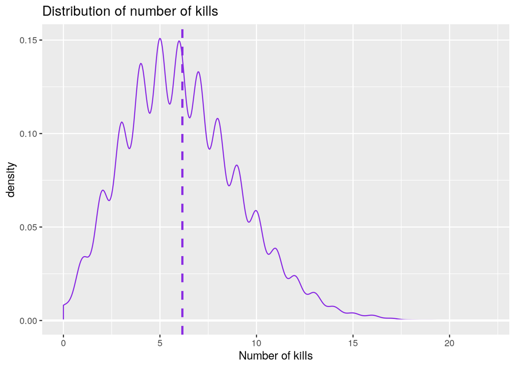

```r
mod_df <- data.frame(kills = c(league_df[,'blueKills'], league_df[,'redKills']))

mod_df %>%
  ggplot() +
  geom_density(mapping=aes(x=kills), color='blueviolet') +
  geom_vline(aes(xintercept=mean(kills)), color='blueviolet', linetype='dashed', size=1) +
  geom_hline(aes(yintercept=0), color='white', size=1) +
  labs(title='Distribution of number of kills') +
  xlab(label='Number of kills')
```

The average number of kills in a League of Legends match tends to be around 6, but many teams manage to score higher or fewer, so to get a better understanding of the data, it would be wise to plot the difference between the number of kills of both teams in a League of Legends match. This code computes the difference in number of kills between both teams in a League of Legends match.

```r
mod_df <- league_df %>%
  mutate(gap=abs(blueKills-redKills))
```

Here is a plot of the difference between the number of kills scored by both teams in a typical League of Legends match.

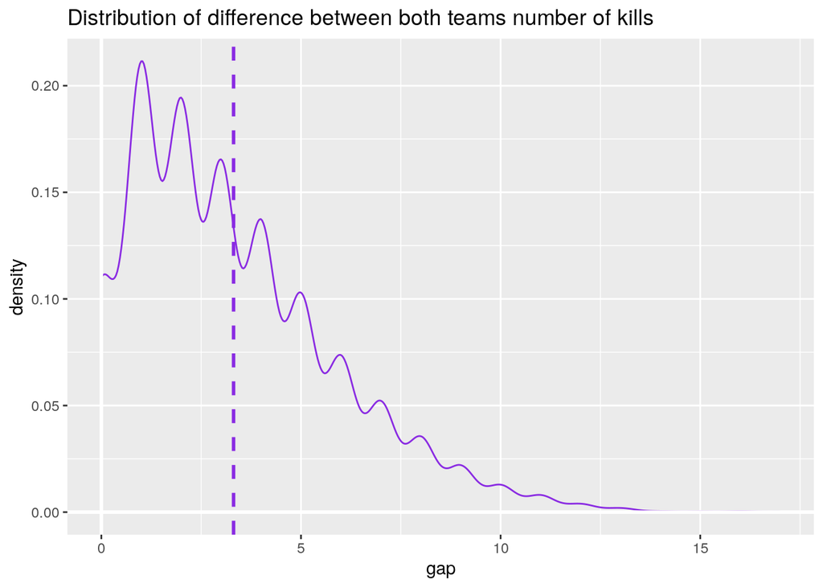

```r
mod_df %>%
  ggplot() +
  geom_density(mapping=aes(x=gap), color='blueviolet') +
  geom_vline(aes(xintercept=mean(gap)), color='blueviolet', linetype='dashed', size=1) +
  geom_hline(aes(yintercept=0), color='white', size=1) +
  geom_vline(aes(xintercept=0), color='white', size=1) +
  labs(title='Distribution of difference between both teams number of kills')
```

Most League of Legend matches involve both teams being pretty close to each other in terms of how many kills each scores, but a significant number of League of Legends matches involve huge differences in the number of kills between each team. One would assume that the team with more kills almost always wins so it would be wise to statistically analyze how a higher number of kills translates to ultimately winning a match. This code computes which team scored more kills in a League of Legends match.

```r
mod_df <- mod_df %>%
  mutate(winner=ifelse(blueKills == 1, 'blue', 'red'), moreKills=ifelse(blueKills > redKills, 'blue', ifelse(redKills > blueKills, 'red', 'equal')), result=ifelse(moreKills == 'equal', 'equal', ifelse(moreKills == winner, 'true', 'false')))
```

Here is a plot of the proportion of League of Legends matches won by the team with more kills versus matches won by the team with less kills.

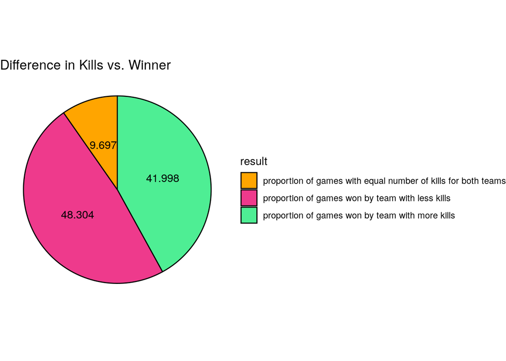

```r
mod_df %>%
  group_by(result) %>%
  add_tally() %>%
  group_by(result) %>%
  summarize(n=round(100*max(n)/nrow(league_df), 3)) %>%
  ggplot(aes(x='', y=n, fill=result)) +
  geom_bar(stat='identity', width=1, color='black') +
  coord_polar('y', start=0) +
  scale_fill_manual(labels=c('equal'='proportion of games with equal number of kills for both teams', 'false'='proportion of games won by team with less kills', 'true'='proportion of games won by team with more kills'), values=c('equal'='orange', 'false'='violetred2', 'true'='seagreen2')) +
  geom_text(aes(label=n), position=position_stack(vjust=0.5)) +
  labs(title='Difference in Kills vs. Winner', color='Legend') +
  theme_void()
```

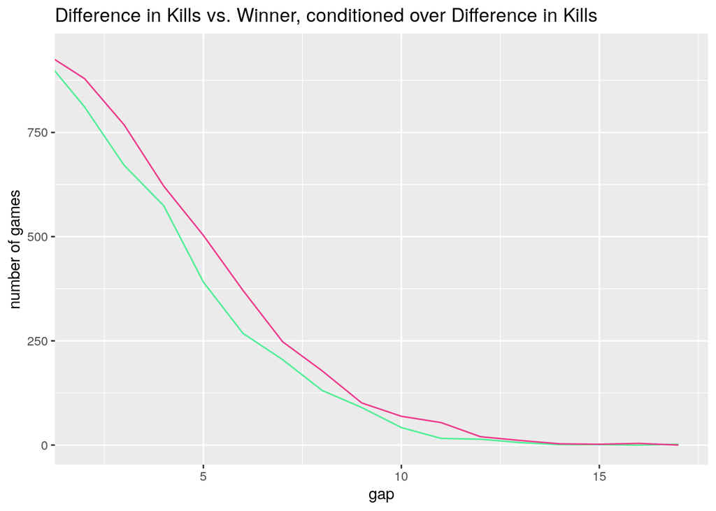

```r
mod_df %>%
  select(gap, result) %>%
  group_by(gap) %>%
  summarize(equal=sum(result=='equal'), true=sum(result=='true'), false=sum(result=='false')) %>%
  ggplot() +
  geom_line(mapping=aes(x=gap, y=true, color='number of games won by team with more kills'), color='seagreen2') +
  geom_line(mapping=aes(x=gap, y=false, color='number of games won by team with less kills'), color='violetred2') +
  ylab(label='number of games') +
  labs(title='Difference in Kills vs. Winner, conditioned over Difference in Kills') +
  coord_cartesian(xlim = c(2, 17))
```

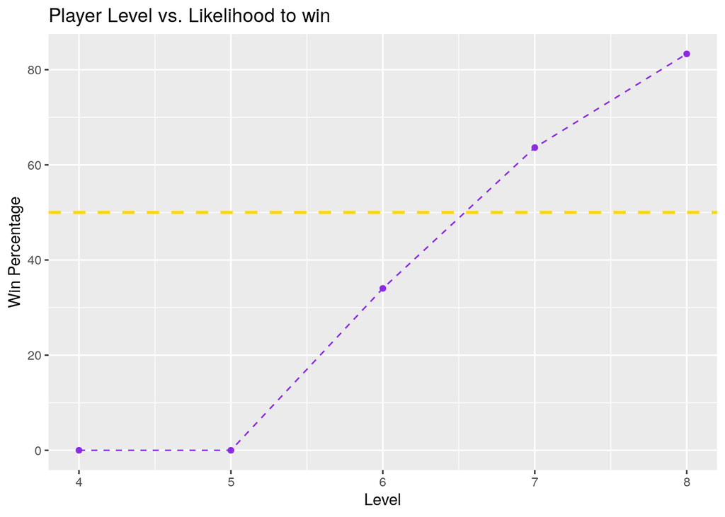

```r
mod_df <- league_df %>%
  mutate(blueFloorLevel=floor(blueAvgLevel), redFloorLevel=floor(redAvgLevel), redWins=ifelse(blueWins, 0, 1))

data.frame(lvl = c(mod_df[,'blueFloorLevel'], mod_df[,'redFloorLevel']), wins = c(mod_df[,'blueWins'], mod_df[,'redWins'])) %>%
  group_by(lvl) %>%
  summarize(wins=100*mean(wins)) %>%
  ggplot() +
  geom_point(mapping=aes(x=lvl, y=wins), color='blueviolet') +
  geom_line(mapping=aes(x=lvl, y=wins), color='blueviolet', linetype='dashed') +
  geom_hline(aes(yintercept=50), color='gold', linetype='dashed', size=1) +
  labs(title='Player Level vs. Likelihood to win') +
  xlab(label='Level') +
  ylab(label='Win Percentage')
```

```r
mod_df <- data.frame(lvl = c(mod_df[,'blueAvgLevel'], mod_df[,'redAvgLevel']), wins = c(mod_df[,'blueWins'], mod_df[,'redWins']))
broom::tidy(lm(lvl ~ wins, data = mod_df))
```

```
## # A tibble: 2 x 5
##   term        estimate std.error statistic p.value
##   <chr>          <dbl>     <dbl>     <dbl>   <dbl>
## 1 (Intercept)    6.81    0.00287    2373.        0
## 2 wins           0.217   0.00406      53.4       0
```

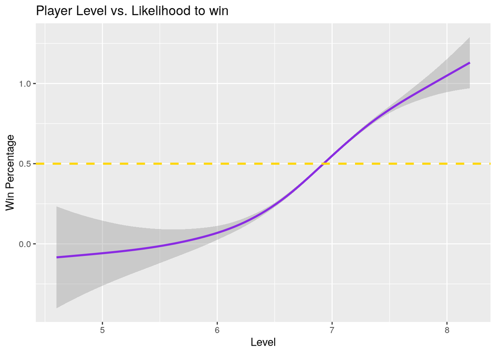

```r
mod_df %>%
  ggplot(mapping=aes(x=lvl, y=wins)) +
  stat_smooth(color='blueviolet') +
  geom_hline(aes(yintercept=.5), color='gold', linetype='dashed', size=1) +
  labs(title='Player Level vs. Likelihood to win') +
  xlab(label='Level') +
  ylab(label='Win Percentage')
```

It has been sufficiently proven that some variables have a significant impact on whether or not a team will win a League of Legends match and some variables do not, or maybe even have a negative impact. The next logical step is to build a model that, given various in-game parameters, will predict if a team will win a League of Legends match.

# MACHINE LEARNING

**Can we predict whether or not blue team wins the match based on these statistics for the first 10 minutes?**

First, we will set up the dataframes that we will be using for this analysis.

```r
outcome_df <- league_df %>%
  select(gameId, blueWins)
outcome_df %>%
  head()
```

```
##       gameId blueWins
## 1 4519157822        0
## 2 4523371949        0
## 3 4521474530        0
## 4 4524384067        0
## 5 4436033771        0
## 6 4475365709        1
```

```r
predictor_df <- league_df %>%
  select(-blueWins)
predictor_df %>%
  head() %>%
  knitr::kable() %>%
  kable_styling(bootstrap_options = "striped", full_width = F) %>% scroll_box(width = "100%", height = "200px")
```

| gameId | blueWardsPlaced | blueWardsDestroyed | blueFirstBlood | blueKills | blueDeaths | blueAssists | blueEliteMonsters | blueDragons | blueHeralds | blueTowersDestroyed | blueTotalGold | blueAvgLevel | blueTotalExperience | blueTotalMinionsKilled | blueTotalJungleMinionsKilled | blueGoldDiff | blueExperienceDiff | blueCSPerMin | blueGoldPerMin | redWardsPlaced | redWardsDestroyed | redFirstBlood | redKills | redDeaths | redAssists | redEliteMonsters | redDragons | redHeralds | redTowersDestroyed | … |
| --- | --- | --- | --- | --- | --- | --- | --- | --- | --- | --- | --- | --- | --- | --- | --- | --- | --- | --- | --- | --- | --- | --- | --- | --- | --- | --- | --- | --- | --- | --- |
| 4519157822 | 28 | 2 | 1 | 9 | 6 | 11 | 0 | 0 | 0 | 0 | 17210 | 6.6 | 17039 | 195 | 36 | 643 | -8 | 19.5 | 1721.0 | 15 | 6 | 0 | 6 | 9 | 8 | 0 | 0 | 0 | 0 | … |
| 4523371949 | 12 | 1 | 0 | 5 | 5 | 5 | 0 | 0 | 0 | 0 | 14712 | 6.6 | 16265 | 174 | 43 | -2908 | -1173 | 17.4 | 1471.2 | 12 | 1 | 1 | 5 | 5 | 2 | 2 | 1 | 1 | 1 | … |
| 4521474530 | 15 | 0 | 0 | 7 | 11 | 4 | 1 | 1 | 0 | 0 | 16113 | 6.4 | 16221 | 186 | 46 | -1172 | -1033 | 18.6 | 1611.3 | 15 | 3 | 1 | 11 | 7 | 14 | 0 | 0 | 0 | 0 | … |
| 4524384067 | 43 | 1 | 0 | 4 | 5 | 5 | 1 | 0 | 1 | 0 | 15157 | 7.0 | 17954 | 201 | 55 | -1321 | -7 | 20.1 | 1515.7 | 15 | 2 | 1 | 5 | 4 | 10 | 0 | 0 | 0 | 0 | … |
| 4436033771 | 75 | 4 | 0 | 6 | 6 | 6 | 0 | 0 | 0 | 0 | 16400 | 7.0 | 18543 | 210 | 57 | -1004 | 230 | 21.0 | 1640.0 | 17 | 2 | 1 | 6 | 6 | 7 | 1 | 1 | 0 | 0 | … |
| 4475365709 | 18 | 0 | 0 | 5 | 3 | 6 | 1 | 1 | 0 | 0 | 15899 | 7.0 | 18161 | 225 | 42 | 698 | 101 | 22.5 | 1589.9 | 36 | 5 | 1 | 3 | 5 | 2 | 0 | 0 | 0 | 0 | … |

```r
differences_df <- predictor_df %>%
  select(c(gameId, blueWardsPlacedDif, blueWardsDestroyedDif, blueFirstBlood, blueKillsDif, blueDeathsDif, blueAssistsDif, blueDragonDif, blueHeraldDif, blueTowersDestroyedDif, blueGoldDiff, blueAvgLevelDif, blueExperienceDiff, blueTotalMinionsKilledDif, blueTotalJungleMinionsKilledDif))

differences_df %>%
  head() %>%
  knitr::kable() %>%
  kable_styling(bootstrap_options = "striped", full_width = F) %>% scroll_box(width = "100%", height = "200px")
```

| gameId | blueWardsPlacedDif | blueWardsDestroyedDif | blueFirstBlood | blueKillsDif | blueDeathsDif | blueAssistsDif | blueDragonDif | blueHeraldDif | blueTowersDestroyedDif | blueGoldDiff | blueAvgLevelDif | blueExperienceDiff | blueTotalMinionsKilledDif | blueTotalJungleMinionsKilledDif |
| --- | --- | --- | --- | --- | --- | --- | --- | --- | --- | --- | --- | --- | --- | --- |
| 4519157822 | 13 | -4 | 1 | 3 | -3 | 3 | 0 | 0 | 0 | 643 | -0.2 | -8 | -2 | -19 |
| 4523371949 | 0 | 0 | 0 | 0 | 0 | 3 | -1 | -1 | -1 | -2908 | -0.2 | -1173 | -66 | -9 |
| 4521474530 | 0 | -3 | 0 | -4 | 4 | -10 | 1 | 0 | 0 | -1172 | -0.4 | -1033 | -17 | 18 |
| 4524384067 | 28 | -1 | 0 | -1 | 1 | -5 | 0 | 1 | 0 | -1321 | 0.0 | -7 | -34 | 8 |
| 4436033771 | 58 | 2 | 0 | 0 | 0 | -1 | -1 | 0 | 0 | -1004 | 0.0 | 230 | -15 | -10 |
| 4475365709 | -18 | -5 | 0 | 2 | -2 | 4 | 1 | 0 | 0 | 698 | 0.0 | 101 | 4 | -17 |

# Logistic Regression on a Single Predictor

We would like to find out if we can predict the outcome of a match based on the statistics for the first 10 minutes. The outcome is binary: win or loss, so this is a classification problem. We would like to be able to use methods that produce continuous outputs, so instead of modeling 0 or 1 directly, we will model the **probability** that blue wins. Let Y be whether or not blue wins, and X be a vector of statistics at 10 minutes in a given game. We seek to estimate the conditional probability p(Y = 1 | X = x).

The simplest type of machine learning model we can use is a linear one. In order to use a linear construction for the inputs, we build a linear model of log-odds. First, let us consider the case with only one predictor variable:

$log(\frac{p(x)}{1-p(x)}) = \beta_0 + \beta_1x$. The ratio $\frac{p(x)}{1-p(x)}$ is called odds. For instance, if the odds are 2 that blue team wins the game, that means that the blue team is twice as likely to win as red team, or that there is a $\frac{2}{3}$ chance that blue wins. In R, we use the glm() function with family=“binomial” to train a logistic regression model.

For our single predictor variable, we will use gold difference. In League of Legends, having more gold is universally thought of as being crucial to winning the game. Gold allows players to buy items, which can increase the amount of health they have or damage they deal. It can also reduce the damage they take or have other useful effects. Thus, it makes sense to choose gold difference as a predictor, because having more gold directly translates to being more capable of winning the game.

```r
#Create final dataframe with all predictors and outcomes
raw_final_df <- differences_df %>%
  inner_join(outcome_df, by="gameId") %>%
  select(-gameId)

#Fit logistical regression model
logis_fit1 <- glm(blueWins~blueGoldDiff, data=raw_final_df, family="binomial")

#Display model parameters
logis_fit1 %>%
  broom::tidy()
```

```
## # A tibble: 2 x 5
##   term          estimate std.error statistic p.value
##   <chr>            <dbl>     <dbl>     <dbl>   <dbl>
## 1 (Intercept)  -0.0122   0.0236       -0.515   0.606
## 2 blueGoldDiff  0.000587 0.0000133    44.2     0
```

By printing out the logist regression model, we can inspect the parameters $\beta_0$ and $\beta_1$. $\beta_0$ is approximately -0.0122, and $beta_1$ is approximately 0.0005867. $\beta_1$ is the parameter that is multiplied by x, so it is the **weight** of x. Recall from the formula that $log(\frac{p(x)}{1-p(x)}) = \beta_0 + \beta_1x$. Thus, the value of $\beta_1$ indicates that on average, the odds that blue wins raise by $e^{0.0005867}$ for each additional unit of gold earned over red team.

However, this observed increase in gold might just be a product of the variance in the dataset. How do we know if it is **statistically significant?** To answer this, we return to the idea of a **null hypothesis**. Assuming that there was no relationship between gold difference and blue winning (null hypothesis), what is the probability that we would observe this relationship between gold difference and winning, given the variance of this dataset? That probability is found in the p.value column of the dataframe, and we can see that it is extremely low (less than 0.0000001). Thus, we know that this relationship is statistically significant. More information about logistic regression can be found here: https://machinelearningmastery.com/logistic-regression-for-machine-learning/

# Preliminary Evaluation - Correct prediction ratio

In order to evaluate how good our model is, we can use accuracy, the ratio of correct predictions to total predictions, as a preliminary measurement. We will explore more robust means of model evaluation in later segments.

Obtaining and evaluating predictions:

```r
logis_pred_prob1 <- predict(logis_fit1, type="response")
logis_pred1 <- ifelse(logis_pred_prob1 > 0.5, 1, 0)
100 - mean(raw_final_df$blueWins != logis_pred1) * 100
```

```
## [1] 72.36562
```

We see that our logistic regression model using only gold difference achieves an accuracy of 72.366%.

# Using Multiple Predictors

In a game of League of Legends, even though gold is the most directly applicable statistic for success, there are a number of other factors that can contribute. For example, destroying towers can grant teams more map space to safely move around, earning more experience gives players extra levels, which can be used to make their spells more powerful, and there exist enemies on the map which either team can kill to give themselves an advantage, the Dragons and Rift Heralds. Dragons provide a small permanent increase in some aspect, and if a team accumulates four dragon kills, they receive a significant added bonus. The Rift Herald allows a team to potentially deal large amounts of damage to enemy towers.

**How can we make a model that takes into account all of these factors?**

Like before, we can use a logistic regression model. However, this time our model will have a vector of predictors, instead of the single predictor of gold difference. Thus, the equation we are modeling will be:

$log(\frac{p(x)}{1-p(x)}) = \beta_0 + \beta_1x_1 + \beta_2x2 + ... + \beta_px_p$, where each $x_i$ is one measurement.

However, now that we are using multiple variables, there is an additional wrinkle. The ranges of the different measurements that we are taking vary greatly. For example, blue team’s gold difference could possibly be in the thousands, while their average level differences will probably not exceed 1 or 2 at the most. The scales of these variables are not comparable, so before we make our model, we have to standardize all the continuous variables. To do this, we will use Z-normalization. We will subtract each value from the mean of that value and divide by the standard deviation. This will scale all the variables so that they all have mean 0 and standard deviation 1, enabling easier comparisons between values.

Here we standardize all the continuous variables using the **scale** function.

```r
standardized_df <- differences_df %>%
  mutate(z_blueWardsPlacedDif = scale(blueWardsPlacedDif)) %>%
  mutate(z_blueWardsDestroyedDif = scale(blueWardsDestroyedDif)) %>%
  mutate(z_blueKillsDif = scale(blueKillsDif)) %>%
  mutate(z_blueDeathsDif = scale(blueDeathsDif)) %>%
  mutate(z_blueAssistsDif = scale(blueAssistsDif)) %>%
  mutate(z_blueTowersDestroyedDif = scale(blueTowersDestroyedDif)) %>%
  mutate(z_blueGoldDiff = scale(blueGoldDiff)) %>%
  mutate(z_blueAvgLevelDif = scale(blueAvgLevelDif)) %>%
  mutate(z_blueExperienceDif = scale(blueExperienceDiff)) %>%
  mutate(z_blueTotalMinionsKilledDif = scale(blueTotalMinionsKilledDif)) %>%
  mutate(z_blueTotalJungleMinionsKilledDif = scale(blueTotalJungleMinionsKilledDif)) %>%
  select(-c(blueWardsPlacedDif, blueWardsDestroyedDif, blueKillsDif, blueDeathsDif, blueAssistsDif,blueTowersDestroyedDif, blueGoldDiff, blueAvgLevelDif, blueExperienceDiff, blueTotalMinionsKilledDif, blueTotalJungleMinionsKilledDif))
standardized_df%>%
  head() %>%
  knitr::kable() %>%
  kable_styling(bootstrap_options = "striped", full_width = F) %>% scroll_box(width = "100%", height = "200px")
```

| gameId | blueFirstBlood | blueDragonDif | blueHeraldDif | z_blueWardsPlacedDif | z_blueWardsDestroyedDif | z_blueKillsDif | z_blueDeathsDif | z_blueAssistsDif | z_blueTowersDestroyedDif | z_blueGoldDiff | z_blueAvgLevelDif | z_blueExperienceDif | z_blueTotalMinionsKilledDif | z_blueTotalJungleMinionsKilledDif |
| --- | --- | --- | --- | --- | --- | --- | --- | --- | --- | --- | --- | --- | --- | --- |
| 4519157822 | 1 | 0 | 0 | 0.50382783 | -1.43672853 | 0.70402757 | -0.70402757 | 0.5231692 | -0.02586442 | 0.2562154 | -0.39856574 | 0.01334134 | -0.04364002 | -1.2747404 |
| 4523371949 | 0 | -1 | -1 | 0.00306865 | -0.03563368 | -0.01102607 | 0.01102607 | 0.5231692 | -3.10435328 | -1.1911937 | -0.39856574 | -0.59331245 | -2.11198093 | -0.5742019 |
| 4521474530 | 0 | 1 | 0 | 0.00306865 | -1.08645482 | -0.96443091 | 0.96443091 | -1.7311189 | -0.02586442 | -0.4835896 | -0.81659642 | -0.52040985 | -0.52840742 | 1.3172521 |
| 4524384067 | 0 | 0 | 1 | 1.08162688 | -0.38590739 | -0.24937728 | 0.24937728 | -0.8640850 | -0.02586442 | -0.5443229 | 0.01946494 | 0.01386207 | -1.07781048 | 0.6167136 |
| 4436033771 | 0 | -1 | 0 | 2.23722499 | 0.66491375 | -0.01102607 | 0.01102607 | -0.1704579 | -0.02586442 | -0.4151118 | 0.01946494 | 0.13727576 | -0.46377177 | -0.6442557 |
| 4475365709 | 0 | 1 | 0 | -0.69029022 | -1.78700224 | 0.46567636 | -0.46567636 | 0.6965760 | -0.02586442 | 0.2786338 | 0.01946494 | 0.07010122 | 0.15026693 | -1.1346327 |

We also attach the outcomes to the dataframe so that we can make our model.

```r
final_df <- standardized_df %>%
  inner_join(outcome_df, by="gameId") %>%
  select(-gameId)
final_df %>%
  head() %>%
  knitr::kable() %>%
  kable_styling(bootstrap_options = "striped", full_width = F) %>% scroll_box(width = "100%", height = "200px")
```

| blueFirstBlood | blueDragonDif | blueHeraldDif | z_blueWardsPlacedDif | z_blueWardsDestroyedDif | z_blueKillsDif | z_blueDeathsDif | z_blueAssistsDif | z_blueTowersDestroyedDif | z_blueGoldDiff | z_blueAvgLevelDif | z_blueExperienceDif | z_blueTotalMinionsKilledDif | z_blueTotalJungleMinionsKilledDif | blueWins |
| --- | --- | --- | --- | --- | --- | --- | --- | --- | --- | --- | --- | --- | --- | --- |
| 1 | 0 | 0 | 0.50382783 | -1.43672853 | 0.70402757 | -0.70402757 | 0.5231692 | -0.02586442 | 0.2562154 | -0.39856574 | 0.01334134 | -0.04364002 | -1.2747404 | 0 |
| 0 | -1 | -1 | 0.00306865 | -0.03563368 | -0.01102607 | 0.01102607 | 0.5231692 | -3.10435328 | -1.1911937 | -0.39856574 | -0.59331245 | -2.11198093 | -0.5742019 | 0 |
| 0 | 1 | 0 | 0.00306865 | -1.08645482 | -0.96443091 | 0.96443091 | -1.7311189 | -0.02586442 | -0.4835896 | -0.81659642 | -0.52040985 | -0.52840742 | 1.3172521 | 0 |
| 0 | 0 | 1 | 1.08162688 | -0.38590739 | -0.24937728 | 0.24937728 | -0.8640850 | -0.02586442 | -0.5443229 | 0.01946494 | 0.01386207 | -1.07781048 | 0.6167136 | 0 |
| 0 | -1 | 0 | 2.23722499 | 0.66491375 | -0.01102607 | 0.01102607 | -0.1704579 | -0.02586442 | -0.4151118 | 0.01946494 | 0.13727576 | -0.46377177 | -0.6442557 | 0 |
| 0 | 1 | 0 | -0.69029022 | -1.78700224 | 0.46567636 | -0.46567636 | 0.6965760 | -0.02586442 | 0.2786338 | 0.01946494 | 0.07010122 | 0.15026693 | -1.1346327 | 1 |

Suppose you wanted to consider the effects of gold, dragons, heralds, and experience:

```r
logis_fit2 <- glm(blueWins~z_blueGoldDiff + blueDragonDif + blueHeraldDif + z_blueExperienceDif + z_blueTowersDestroyedDif, data=final_df, family="binomial")
logis_fit2 %>%
  broom::tidy()
```

```
## # A tibble: 8 x 5
##   term                     estimate std.error statistic  p.value
##   <chr>                       <dbl>     <dbl>     <dbl>    <dbl>
## 1 (Intercept)               -0.372     0.0677     -5.50 3.86e- 8
## 2 z_blueGoldDiff             1.02      0.0594     17.1  1.01e-65
## 3 blueDragonDif0             0.255     0.0625      4.08 4.58e- 5
## 4 blueDragonDif1             0.632     0.0550     11.5  1.38e-30
## 5 blueHeraldDif0             0.0805    0.0682      1.18 2.38e- 1
## 6 blueHeraldDif1             0.158     0.0845      1.87 6.18e- 2
## 7 z_blueExperienceDif        0.437     0.0556      7.87 3.55e-15
## 8 z_blueTowersDestroyedDif  -0.0742    0.0315     -2.35 1.85e- 2
```

Unlike the previous model, where the weight, $\beta_1$, represented how much the odds would increase by one additional unit of gold difference, the interpretation for multiple logistic regression is slightly more complicated. In this case, the associated weight for gold difference is 1.0178. This means that **holding all other variables constant**, the odds that blue team wins raises by $e^{1.0178}$ per standard deviation of gold difference.

Furthermore, there are now categorical attributes mixed in, whose interpretation also varies slightly. For categorical variables, the weights are interpreted as improvements over a baseline. As can be seen in from the table, there is no entry for the -1 categories of blue dragons and blue heralds (if the enemy team killed the dragon or herald). That indicates that the -1 values are used as base lines. Thus, for example, the value for blueDragonDif0 is 0.2549, indicating that the odds that blue team wins is greater by $e^{0.2549}$ compared to if the enemy team kills the dragon.

Finally, it is important to note that not all of the relationships being displayed are statistically significant. For example, the p-value for blueHeraldDif0 is 0.237, which indicates there is a 23.7% chance that this relationship could just be variance in the dataset. This is also a result that we somewhat expect, because in League of Legends, killing the Rift Herald is usually only impactful if it earns the team additional gold. Thus, **holding all other factors constant**, it makes sense that killing the Rift Herald would not be particularly predictive of victory.

Now we evaluate the model, once again using accuracy.

```r
logis_pred_prob2 <- predict(logis_fit2, type="response")
logis_pred2 <- ifelse(logis_pred_prob2 > 0.5, 1, 0)
100 - mean(final_df$blueWins != logis_pred2) * 100
```

```
## [1] 73.3475
```

We achieve a slight improvement over the previous logistical regression model. We can also try other variables. For example, the in-game only shows each team’s kills, towers, levels, total minions killed, dragons, heralds, and a number for each player called vision score. Vision score is not available in this dataset, but we can substitute it with wards placed and killed. Therefore, we can construct a model using only the knowledge that would be available to players in-game.

```r
logis_fit3 <- glm(blueWins~blueFirstBlood + blueDragonDif + blueHeraldDif + z_blueKillsDif + z_blueDeathsDif + z_blueAssistsDif + z_blueWardsPlacedDif + z_blueWardsDestroyedDif +  z_blueTowersDestroyedDif + z_blueAvgLevelDif + z_blueTotalMinionsKilledDif, data=final_df, family="binomial")
logis_fit3 %>%
  broom::tidy()
```

```
## # A tibble: 13 x 5
##    term                        estimate std.error statistic  p.value
##    <chr>                          <dbl>     <dbl>     <dbl>    <dbl>
##  1 (Intercept)                 -0.480      0.0711   -6.76   1.38e-11
##  2 blueFirstBlood1              0.130      0.0499    2.60   9.35e- 3
##  3 blueDragonDif0               0.246      0.0618    3.97   7.15e- 5
##  4 blueDragonDif1               0.611      0.0549   11.1    8.57e-29
##  5 blueHeraldDif0               0.133      0.0674    1.98   4.81e- 2
##  6 blueHeraldDif1               0.260      0.0836    3.11   1.90e- 3
##  7 z_blueKillsDif               0.738      0.0587   12.6    3.43e-36
##  8 z_blueAssistsDif             0.0167     0.0445    0.375  7.08e- 1
##  9 z_blueWardsPlacedDif         0.00190    0.0238    0.0799 9.36e- 1
## 10 z_blueWardsDestroyedDif      0.0123     0.0241    0.509  6.11e- 1
## 11 z_blueTowersDestroyedDif     0.0756     0.0302    2.51   1.22e- 2
## 12 z_blueAvgLevelDif            0.468      0.0423   11.1    2.17e-28
## 13 z_blueTotalMinionsKilledDif  0.208      0.0296    7.02   2.18e-12
```

```r
logis_pred_prob3 <- predict(logis_fit3, type="response")
logis_pred3 <- ifelse(logis_pred_prob3 > 0.5, 1, 0)
100 - mean(final_df$blueWins != logis_pred3) * 100
```

```
## [1] 72.28464
```

Note that our accuracy actually decreased compared to both the model using only gold and the previous one, but that does not necessarily mean that this model is worse, since it is more sensitive to changes in parameters.

# Other Classifiers: Regression Trees

Besides logistic regression, we can also use other machine learning methods to attempt to predict if blue team wins. In this tutorial, we will only explore a single additional method, the regression tree. Trees have the advantage of being able to more effectively divide the possible outputs based on the inputs compared to logistical regression. We begin with a basic example, once more only using gold difference (this time the standardized one).

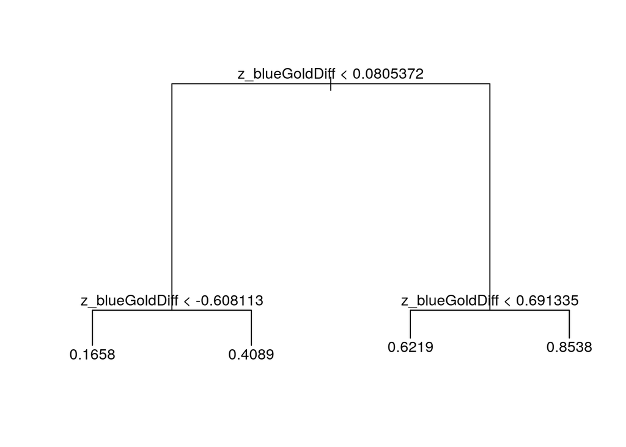

```r
#Create regression tree
win_tree <- tree(blueWins~z_blueGoldDiff, data=final_df)
plot(win_tree)
#Display tree
text(win_tree, pretty=1)
```

Although whether or not blue team wins is a categorical output, we are using the tree to predict the probability that blue wins, which is continuous. This probability can be easily converted to whenever we want by converting all alues above 0.5 to yes and the rest to no. With regression trees, the interpretation is relatively easier, compared to logistic regression. As can be seen from the output, the tree makes four possible predictions, based on what interval the gold difference falls into. For example, if the gold differene is between 0.0805372 and 0.691335 standard deviations, the tree predicts a win likelihood of 0.6219. In general, regression trees can be thought of dividing the region of predictors into different spaces and taking the mean output for each. For more information on tree-based methods, visit this link: https://towardsdatascience.com/decision-tree-and-random-forest-explained-8d20ddabc9dd

#K-Fold Cross Validation and AUROC Evaluation

Up until this point, we have been evaluating our models using the entire dataset and simply taking the accuracy. Now, we will discuss more robust evaluation techniques. First, it is important that we do not evaluate on the same data that we use to create our model. This is because the dataset may have specific characteristics (noise and variance) within it that do not apply to the problem as a whole. For example, it is possible that in our data, blue wins more often when they kill a dragon and have a gold difference of between 1500 and 2000 compared to in reality. Our model may learn this idiosyncracy of our data, which would cause it to perform worse on unseen data, and in any practical application of our model, we are only interested in unseen data since we already know if blue wins for all the games in our dataset. This problem, where the model is only good at predicting the data that we already have, is called **overfitting**.

In the best case scenario, we would have a separate dataset simply used for testing, but in absence of such a set, we use a **validation set** instead. We divide the data se have into a portion we use to create the model, the training set, and a portion which we use to evaluate it, the validation set. Ideally, we would like the validation set to be as reflective of reality as possible, but since there is no easy way to do that, we instead use multiple different splits of the dataset and create and evaluate the model on each. In other words, we divide the dataset into **k** groups, use **k-1** of them to create the model and the last group to evaluate, and do this with all k groups. This is called **k-fold cross validation**.

Finally, instead of accuracy, we will use a measurement called AUROC (Area Under the Receiver Operating Characteristics). While accuracy might seem like a perfectly fine evaluation metric, it is actually not very robust to different possibilities in the data. For example, consider a dataset which contains 90% blue victories. A model could simply predict blue wins for every single, and achieve a seemingly good 90% accuracy rate without even considering the parameters. This model has no distinguishing capability between games. In our dataset, this is not the case, but even though the data is fairly balanced, we are still interested in models with greater distinguishing capability between games. In order to understand this more, we will define two terms, **True Positive Rate (TPR)** and **False Positive Rate (FPR)**. TPR is $\frac{Model\;Correctly\;Predicts\;Blue\;Wins}{Blue\;Actually\;Wins}$, the ratio of correct positive predictions that our model makes versus the true set of positive examples. Meanwhile, FPR is $\frac{Model\;Incorrectly\;Predicts\;Blue\;Wins}{Blue\;Actually\;Loses}$, the number of times the model predicts blue wins when they actually lose over the number of actual losses. It makes sense that we can tweek our model to have better TPR or better FPR at the cost of the other. We can do this by adjusting what probability we consider to be confident enough to be a “Yes” prediction. For instance, if we only predict “Yes” when the probability is very high, our FPR will be very low since we will almost never predict that blue wins unless they actually win. However, our TPR will be low since many times blue will actually win but we will predict that they lose.

To consider a practical reason that we care, there is a function in League of Legends that allows a team to surrender. The above model would allow us to know when red team should probably surrender, since if it predicts that blue will win, blue will almost definitely win, even if blue doesn’t always lose of it predicts that blue will lose. The ROC (Receiver Operating Characteristics) is a curve that plots TPR against FPR. We can evaluate a model’s performance by taking the area under this curve, which is AUROC. This measurement makes sense becauase TPR should never decrease as FPR increases, since as FPR increases, the predictions become more tolerant towards predicting positive, which will in turn allow the model to catch more of the actual positives, increasing TPR. We want the model to rapidly approach of TPR of 1 even at low FPR, so using the area under the curive will do this.

More information on these topics can be found at the following links:

K-fold cross validation: https://www.analyticsvidhya.com/blog/2018/05/improve-model-performance-cross-validation-in-python-r/

AUROC: https://glassboxmedicine.com/2019/02/23/measuring-performance-auc-auroc/

Now, we will use 10-fold cross validation on both a tree and a logistic regression model to evaluate which one performs better.

```r
set.seed(1234)

#Create 10 folds
cv_partition <- createFolds(final_df$blueWins, k=10)

get_roc_data <- function(cv_partition, mode) {
  mean_fpr <- seq(0, 1, len=100)
  aucs <- numeric(length(cv_partition))

  # iterate over folds
  res <- lapply(seq_along(cv_partition),  function(i) {

    if (mode == "logis") {
      #Train logistic regression model and predict
      logis_fit <- glm(blueWins~z_blueGoldDiff + blueDragonDif + blueHeraldDif + z_blueExperienceDif + z_blueTowersDestroyedDif + z_blueTotalMinionsKilledDif, data=final_df[-cv_partition[[i]],], family="binomial")
      preds <- predict(logis_fit, newdata=final_df[cv_partition[[i]],], type='response')

    }
    else if (mode=='tree'){
      # Train the decision tree model and predict
      fit <- tree(blueWins~z_blueGoldDiff + blueDragonDif + blueHeraldDif + z_blueExperienceDif + z_blueTowersDestroyedDif + z_blueTotalMinionsKilledDif, data = final_df[-cv_partition[[i]],])
      pruned_fit <- prune.tree(fit, best=3)

      # make predictions on the holdout set
      preds <- predict(pruned_fit, newdata=final_df[cv_partition[[i]],],type="vector")
    }

    # compute true and false positive rate from the hold out set
    perf <- ROCR::prediction(preds, final_df$blueWins[cv_partition[[i]]]) %>%
      ROCR::performance(measure="tpr", x.measure="fpr")

    fpr <- unlist(perf@x.values)
    tpr <- unlist(perf@y.values)

    # interpolate the roc curve over 0, 1 range
    interp_tpr <- approxfun(fpr, tpr)(mean_fpr)
    interp_tpr[1] <- 0.0

    # collect values for this fold
    data_frame(fold=rep(i, length(mean_fpr)), fpr=mean_fpr, tpr=interp_tpr)
  })

  # combine values across all folds into a single data frame
  do.call(rbind, res)
}

# calculate area under the ROC curve from tpr and fpr values across folds
compute_auc <- function(curve_df) {
  curve_df %>%
    group_by(fold) %>%
    summarize(auc=pracma::trapz(fpr, tpr))
}

#get performance data for decision tree
tree_curve_df <- get_roc_data(cv_partition, mode="tree")
tree_auc_df <- compute_auc(tree_curve_df)

#get performance data for logistic regression
logis_curve_df <- get_roc_data(cv_partition, mode="logis")
logis_auc_df <- compute_auc(logis_curve_df)
```

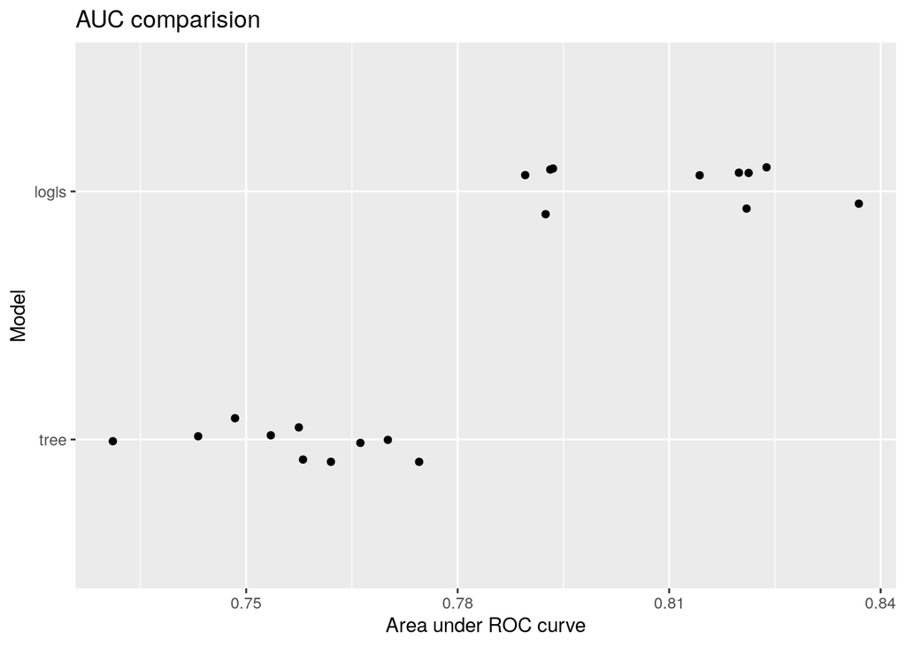

```r
# combine performance data for both models
# into one data frame, adding column to indicate which model was used
curve_df <- tree_curve_df %>%
  mutate(model="tree") %>%
  rbind(mutate(logis_curve_df, model="logis")) %>%
  mutate(model = factor(model, levels=c("tree", "logis")))

auc_df <- tree_auc_df %>%
  mutate(model="tree") %>%
  rbind(mutate(logis_auc_df, model="logis")) %>%
  mutate(model = factor(model, levels=c("tree", "logis")))

# plot distribution of areas
ggplot(auc_df, aes(x=model, y=auc)) +
  geom_jitter(position=position_jitter(0.1)) +
  coord_flip() +
  labs(title="AUC comparision",
       x="Model",
       y="Area under ROC curve")
```

Visually, we can see that the logistical model gets higher AUROC for all folds compared to the regression tree model. We can use linear regression, fitting a line to these points, to test for specific improvement on area under ROC.

```r
model_tab <- auc_df %>%
  lm(auc~model,data=.) %>%
  tidy()

model_tab
```

```
## # A tibble: 2 x 5
##   term        estimate std.error statistic  p.value
##   <chr>          <dbl>     <dbl>     <dbl>    <dbl>
## 1 (Intercept)   0.756    0.00476    159.   8.75e-30
## 2 modellogis    0.0542   0.00673      8.04 2.26e- 7
```

We see a statistically significant increase in AUROC for the logistical model, an approximate an increase of 0.05415 in area.

We can also plot the ROC curves to show visually how the models perform.

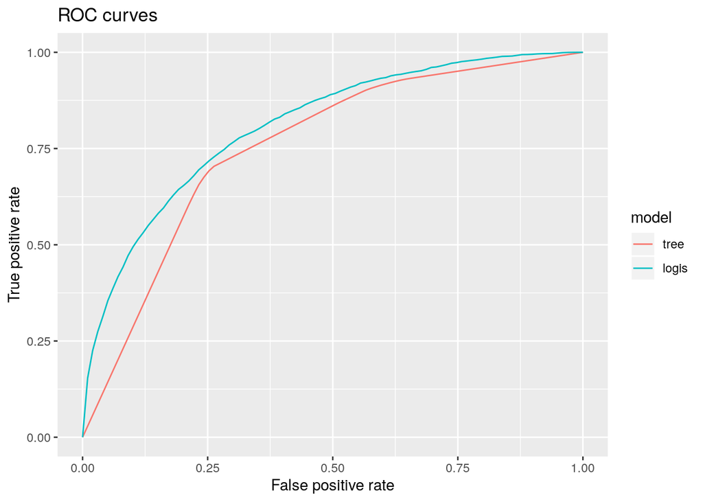

```r
curve_df %>%
  group_by(model, fpr) %>%
  summarize(tpr = mean(tpr)) %>%
  ggplot(aes(x=fpr, y=tpr, color=model)) +
    geom_line() +
    labs(title = "ROC curves",
         x = "False positive rate",
         y = "True positive rate")
```

The logistic model’s curve is above the tree’s, indicating that it performs better (gets a better true positive rate) for all false positive rates.

# Final Thoughts:

We were able to use logistic regression to create a model that predicts when blue team will win with reasonable accuracy. We evaluated different approaches, using different predictors, and we used K-fold cross validation to test different types of models. However, we were unable to achieve an exceptionally high degree of success. This result was more or less expected because while the first 10 minutes of a League of Legends game is definitely related to the result, there are many games where a team who is behind at 10 minutes can make a comeback to win the game. This is reflected in the relatively low accuracy and AUROC of our models.

# Citations

Brownlee, J. (2019, August 12). Logistic Regression for Machine Learning. Retrieved May 18, 2020,from https://machinelearningmastery.com/logistic-regression-for-machine-learning/

Yildirim, S. (2020, February 11). Decision Tree and Random Forest-Explained. Retrieved May 18, 2020, from https://towardsdatascience.com/decision-tree-and-random-forest-explained-8d20ddabc9dd

Ray, S. (2019, September 04). Improve Your Model Performance using Cross Validation (in Python / R). Retrieved May 18, 2020, from https://www.analyticsvidhya.com/blog/2018/05/improve-model-performance-cross-validation-in-python-r/

Draelos, R. (2020, February 02). Measuring Performance: AUC (AUROC). Retrieved May 18, 2020, from https://glassboxmedicine.com/2019/02/23/measuring-performance-auc-auroc/